# SEUS Temp Data from Buoys

```r
library(data.table)
library(ggplot2)
library(usmap)
library(lme4)
library(tidyverse)
library(lubridate)

savannah <- fread("NOAA_buoy_data/41008_savannah.csv")
fryingpanNC <- fread("NOAA_buoy_data/fpsn7_fryingpanNC.csv")
canaveral <- fread("NOAA_buoy_data/41009_canaveral.csv")
```

```
|--------------------------------------------------|
|==================================================|
```

```r
hatteras <- fread("NOAA_buoy_data/41001_east_hatteras.csv")
staugustine <- fread("NOAA_buoy_data/sauf1_staugustineFL.csv")
SC_old <- fread("NOAA_buoy_data/41005_SC.csv")
charleston <- fread("NOAA_buoy_data/41004_charleston.csv")
savannahlight <- fread("NOAA_buoy_data/svls1_savannahlight.csv")
wrightsvilleNC <- fread("NOAA_buoy_data/41037_wrightsvilleNC.csv")
```

```r
hatteras.r <- hatteras[, .(lat, lon, Location, YYYY, MM, DD, hh, ATMP, WTMP)]
fryingpanNC.r <- fryingpanNC[, .(lat, lon, Location, YYYY, MM, DD, hh, ATMP, WTMP)]
wrightsvilleNC.r <- wrightsvilleNC[, .(lat, lon, Location, YYYY, MM, DD, hh, ATMP, WTMP)]
charleston.r <- charleston[, .(lat, lon, Location, YYYY, MM, DD, hh, ATMP, WTMP)]
SC_old.r <- SC_old[, .(lat, lon, Location, YYYY, MM, DD, hh, ATMP, WTMP)]
savannah.r <- savannah[,.(lat, lon, Location, YYYY, MM, DD, hh, ATMP, WTMP)]
savannahlight.r <- savannahlight[,.(lat, lon, Location, YYYY, MM, DD, hh, ATMP, WTMP)]
staugustine.r <- staugustine[, .(lat, lon, Location, YYYY, MM, DD, hh, ATMP, WTMP)]
canaveral.r <- canaveral[, .(lat, lon, Location, YYYY, MM, DD, hh, ATMP, WTMP)]

#summary(hatteras.r)
#summary(fryingpanNC.r)
#summary(wrightsvilleNC.r)
#summary(charleston.r)
#summary(SC_old.r)
#summary(savannah.r)
#summary(savannahlight.r)
#summary(staugustine.r)
#summary(canaveral.r)
```

```r
se_hourly_temp <- rbind(savannah.r, fryingpanNC.r, canaveral.r, hatteras.r, staugustine.r, wrightsvilleNC.r, charleston.r, savannahlight.r, SC_old.r)

se_hourly_temp <- data.table(se_hourly_temp)

se_hourly_temp[, Location := as.factor(Location)]

summary(se_hourly_temp)
```

```
      lat             lon                        Location           YYYY            MM
 Min.   :28.51   Min.   :-81.27   41009_canaveral    :400282   Min.   :1980   Min.   : 1.000
 1st Qu.:28.51   1st Qu.:-80.87   sauf1_staugustineFL:233467   1st Qu.:1992   1st Qu.: 4.000
 Median :31.40   Median :-80.19   41001_east_hatteras:224680   Median :1999   Median : 7.000
 Mean   :31.42   Mean   :-78.79   fpsn7_fryingpanNC  :201600   Mean   :1999   Mean   : 6.525
 3rd Qu.:33.48   3rd Qu.:-77.59   41008_savannah     :186762   3rd Qu.:2007   3rd Qu.:10.000
 Max.   :34.72   Max.   :-72.32   41004_charleston   :174263   Max.   :2014   Max.   :12.000
                                  (Other)            :163990
       DD              hh            ATMP                WTMP
 Min.   : 1.00   Min.   : 0.00   Length:1585044     Min.   : -6.1
 1st Qu.: 8.00   1st Qu.: 5.00   Class :character   1st Qu.: 21.3
 Median :16.00   Median :11.00   Mode  :character   Median : 25.4
 Mean   :15.73   Mean   :11.49                      Mean   :214.9
 3rd Qu.:23.00   3rd Qu.:17.00                      3rd Qu.: 28.7
 Max.   :31.00   Max.   :23.00                      Max.   :999.0
```

```r
#years for each region
se_hourly_temp %>%
  group_by(Location) %>%
  summarise(min(YYYY), max(YYYY))
```

| Location | min(YYYY) | max(YYYY) |
| --- | --- | --- |
| 41001_east_hatteras | 1980 | 2013 |
| 41004_charleston | 1980 | 2014 |
| 41005_SC | 1980 | 1982 |
| 41008_savannah | 1988 | 2014 |
| 41009_canaveral | 1988 | 2014 |
| 41037_wrightsville | 2005 | 2014 |
| fpsn7_fryingpanNC | 1984 | 2008 |
| sauf1_staugustineFL | 1986 | 2014 |
| svls1_savannahlight | 1985 | 1996 |

Turn any temp values over 50 to NA

```r
se_hourly_temp[WTMP > 50, WTMP := NA]


se_hourly_temp.narm <- se_hourly_temp[complete.cases(WTMP, Location)]

levels(se_hourly_temp$Location)
```

```
[1] "41001_east_hatteras" "41004_charleston"    "41005_SC"            "41008_savannah"
[5] "41009_canaveral"     "41037_wrightsville"  "fpsn7_fryingpanNC"   "sauf1_staugustineFL"
[9] "svls1_savannahlight"
```

Plot year versus whether we have data

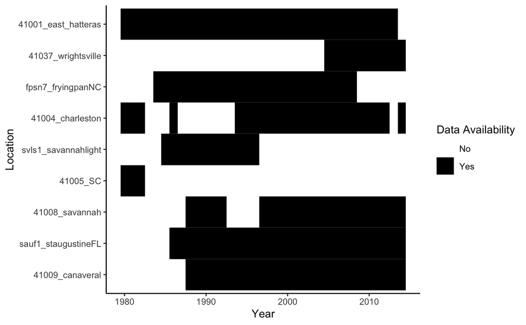

```r
year_site_combos <- expand.grid(Location = levels(se_hourly_temp$Location), YYYY = c(1980:2014))

true_year_site_combos <- unique(se_hourly_temp, by = c("Location", "YYYY"))[,.(Location, YYYY)][, exist := 1]

data_over_time <- rbind(year_site_combos, true_year_site_combos, fill = T)

data_over_time.u <- unique(data_over_time, by = c("Location", "YYYY"), fromLast = T)

data_over_time.u[is.na(data_over_time.u)] <- 0

data_over_time.u$Location <- factor(data_over_time.u$Location, levels = c( "41009_canaveral", "sauf1_staugustineFL", "41008_savannah","41005_SC", "svls1_savannahlight", "41004_charleston", "fpsn7_fryingpanNC","41037_wrightsville",  "41001_east_hatteras" ))

ggplot(data = data_over_time.u, aes(x = YYYY, y = Location, fill = as.factor(exist))) +
  geom_tile() +
  scale_fill_manual(breaks = c("0", "1"), values = c("white", "black"), labels = c("No", "Yes")) +
  theme_classic() +
  labs(x="Year", "Buoy ID and Location", fill = "Data Availability")
```

```r
NA
NA
```

```r
se_hourly_temp.narm[,month_avg := mean(WTMP, na.rm = T), by = c("Location", "YYYY", "MM")]
se_hourly_temp.narm[,date := paste(YYYY, MM, sep = "-")]
se_hourly_temp.narm[,year := as.numeric(YYYY)]
se_hourly_temp.narm[,month := as.numeric(MM)]

se_hourly_temp.narm[,date.f := ymd(date, truncated = 1)]
```

Now, I will model

mod <- lmer(T_t,i ~ YM_t + (1|B_i)) for each month-year t and each buoy i

```r
load("seus_temp_mod.RData")
```

```r
se_hourly_temp.narm$Location <- factor(se_hourly_temp.narm$Location)

Location <- levels(as.factor(se_hourly_temp.narm$Location))
month <- c(1:12)
year <- c(1980:2014)
date.f <- levels(as.factor(se_hourly_temp.narm$date.f))
all_combinations <- expand.grid(Location, date.f)
names(all_combinations) <- c("Location", "date.f")
```

```r
preds <- predict(seus_temp_mod, newdata = all_combinations)

head(all_combinations)
```

|  | Location | date.f |
| --- | --- | --- |
| 1 | 41001_east_hatteras | 1980-01-01 |
| 2 | 41004_charleston | 1980-01-01 |
| 3 | 41005_SC | 1980-01-01 |
| 4 | 41008_savannah | 1980-01-01 |
| 5 | 41009_canaveral | 1980-01-01 |
| 6 | 41037_wrightsville | 1980-01-01 |

```r
predicted_sst_seus_monthly <- cbind(all_combinations, preds)
```

Average across months

```r
predicted_sst_seus_monthly <- data.table(predicted_sst_seus_monthly)
predicted_sst_seus_monthly[, year := year(date.f)][, month := month(date.f)]
```

[output not shown]

```r
predicted_sst_seus_monthly[, sst_month_sst := mean(preds), by = c("month", "year")]

predicted_sst_seus_monthly_avg <- unique(predicted_sst_seus_monthly, by = c("year", "month"))

save(predicted_sst_seus_monthly_avg, file = "predicted_sst_seus_monthly_avg.RData")
```

Creating full temp variables, will have to go 12 months before first trawl which occurs in April

- mean_sbt_temp_change_lag
- mean_sbt_temp_change_abs_lag

```r
load("hauls_fulltempdata.Rdata")
hauls.seus <- hauls[region == "SCDNR_SEUS"] #it occured in April typically

hauls.seus[,min(as.numeric(month)), by = "year"]
```

| year | V1 |
| --- | --- |
| 1989 | 7 |
| 1990 | 4 |
| 1991 | 4 |
| 1992 | 4 |
| 1993 | 4 |
| 1994 | 4 |
| 1995 | 4 |
| 1996 | 4 |
| 1997 | 4 |
| 1998 | 4 |

[output cut: 17 more lines]

```r
#add month julian
#how many months?
year_month_key <- predicted_sst_seus_monthly_avg[, .N, by = c('year', 'month')][,1:2]
max_julian_month <- nrow(year_month_key)

#sequence of 1:420
julian_months <- seq(1, max_julian_month, by=1)

#earliest = April, 12 months B4 April

year_month_key <- cbind(year_month_key, "month_julian" = julian_months)
```

I need to use this key to add julian month to data tables for sst and sbt.

```r
#surface
predicted_sst_seus_monthly_avg <- predicted_sst_seus_monthly_avg[year_month_key, on = c(year = 'year', month = 'month')]
```

```r
  #surface
    #raw
temp.vars <- c("mean", "max", "min", "seas")
      predicted_sst_seus_monthly_avg[,mean_sst_temp :=numeric(.N)]
      predicted_sst_seus_monthly_avg[,max_sst_temp :=numeric(.N)]
      predicted_sst_seus_monthly_avg[,min_sst_temp :=numeric(.N)]
      predicted_sst_seus_monthly_avg[,seas_sst_temp :=numeric(.N)]

#lag raw
      #new columns
raw.lag.sst.col.names <- CJ(temp.vars, 1:10)[, paste(temp.vars, 1:10, sep ="_sst_temp_lag")] #generate new raw column names

      #loop to make new column names
predicted_sst_seus_monthly_avg[ , raw.lag.sst.col.names[1:40] := numeric(.N) ]
      #ended here


    #change
predicted_sst_seus_monthly_avg[, mean_sst_temp_change := numeric(.N)]
predicted_sst_seus_monthly_avg[, max_sst_temp_change := numeric(.N)]
predicted_sst_seus_monthly_avg[, min_sst_temp_change := numeric(.N)]
predicted_sst_seus_monthly_avg[, seas_sst_temp_change := numeric(.N)]


    #lag change
      #new columns
      change.lag.sst.col.names <- CJ(temp.vars, 1:9)[, paste(temp.vars, 1:9, sep ="_sst_temp_change_lag")]

      #loop to make new column names
      predicted_sst_seus_monthly_avg[ ,change.lag.sst.col.names[1:36]:=numeric(.N) ]

    #abs
    predicted_sst_seus_monthly_avg[, mean_sst_temp_change_abs := numeric(.N)]
    predicted_sst_seus_monthly_avg[, max_sst_temp_change_abs := numeric(.N)]
    predicted_sst_seus_monthly_avg[, min_sst_temp_change_abs := numeric(.N)]
    predicted_sst_seus_monthly_avg[, seas_sst_temp_change_abs := numeric(.N)]

    #lag abs
      abs.change.lag.sst.col.names <- CJ(temp.vars, 1:9)[, paste(temp.vars, 1:9, sep ="_sst_temp_change_abs_lag")]

      #loop to make new column names
      predicted_sst_seus_monthly_avg[ ,abs.change.lag.sst.col.names[1:36]:=numeric(.N) ]



#now, loop to fill these new columns, START AT 121
setorder(predicted_sst_seus_monthly_avg, year, month)
first_year <- which(predicted_sst_seus_monthly_avg==1990, arr.ind = T)[1,1][[1]]
for (i in first_year:nrow(predicted_sst_seus_monthly_avg)) {
    this_month_julian <- predicted_sst_seus_monthly_avg$month_julian[i] #identify month/year
    monthstosubtract <- seq(from = 11, by = 12, length.out = 11)

    this_month_julian_reverse <- NA #month/year combo back in time

    for (j in 1:length(monthstosubtract)){
      this_month_julian_reverse[j] <- this_month_julian-monthstosubtract[j]
    }

  #surface raw
    subset_sst <- predicted_sst_seus_monthly_avg[month_julian >= this_month_julian_reverse[1] & predicted_sst_seus_monthly_avg$month_julian <= this_month_julian]
    predicted_sst_seus_monthly_avg[(i),mean_sst_temp :=mean(subset_sst$sst_month_sst)] #mean temp over the past 12 months
    predicted_sst_seus_monthly_avg[(i),max_sst_temp :=max(subset_sst$sst_month_sst)] #max temp over the past 12 months
    predicted_sst_seus_monthly_avg[(i),min_sst_temp :=min(subset_sst$sst_month_sst)] #min temp over the past 12 months
    predicted_sst_seus_monthly_avg[(i),seas_sst_temp := max_sst_temp - min_sst_temp] #seasonality over the past 12 months

  #surface raw lags
      for (w in 2:length(this_month_julian_reverse)) {

        subset_sst <- predicted_sst_seus_monthly_avg[month_julian >= this_month_julian_reverse[w] & month_julian < this_month_julian_reverse[w-1]] #subsets to correct year

        indx <- which(colnames(predicted_sst_seus_monthly_avg) == paste0("mean_sst_temp_lag", w-1)) #finds column number with right name
        predicted_sst_seus_monthly_avg[(i),(indx) := mean(subset_sst$sst_month_sst)] #assigns value to that cell
        indx <- which(colnames(predicted_sst_seus_monthly_avg) == paste0("max_sst_temp_lag", w-1))
        predicted_sst_seus_monthly_avg[(i),(indx) := max(subset_sst$sst_month_sst)]
        indx <- which(colnames(predicted_sst_seus_monthly_avg) == paste0("min_sst_temp_lag", w-1))
        predicted_sst_seus_monthly_avg[(i),(indx) := min(subset_sst$sst_month_sst)]
        indx <- which(colnames(predicted_sst_seus_monthly_avg) == paste0("seas_sst_temp_lag", w-1))
        predicted_sst_seus_monthly_avg[(i),(indx) := (get(paste0("max_sst_temp_lag", w-1))-get(paste0("min_sst_temp_lag", w-1)))]
      }

    #surface change
    predicted_sst_seus_monthly_avg[(i),mean_sst_temp_change :=  mean_sst_temp-mean_sst_temp_lag1]
    predicted_sst_seus_monthly_avg[(i),max_sst_temp_change :=  max_sst_temp-max_sst_temp_lag1]
    predicted_sst_seus_monthly_avg[(i),min_sst_temp_change :=  min_sst_temp-min_sst_temp_lag1]
    predicted_sst_seus_monthly_avg[(i),seas_sst_temp_change :=  seas_sst_temp-seas_sst_temp_lag1]

    #surface lag change
    for (h in 1:9) {
  #--mean
      indx_raw <- which(colnames(predicted_sst_seus_monthly_avg) == paste0("mean_sst_temp_lag", h))
      indx_raw.p1 <- indx_raw + 1

      temp_change <- predicted_sst_seus_monthly_avg[(i), ..indx_raw]-predicted_sst_seus_monthly_avg[(i), ..indx_raw.p1] #change from lag2-lag1 in raw temp

      indx_change <- which(colnames(predicted_sst_seus_monthly_avg) == paste0("mean_sst_temp_change_lag", h)) #finds column number with right name to fill now
      predicted_sst_seus_monthly_avg[(i),(indx_change) := temp_change] #assigns value to that cell
  #--max
      indx_raw <- which(colnames(predicted_sst_seus_monthly_avg) == paste0("max_sst_temp_lag", h))
      indx_raw.p1 <- indx_raw + 1

      temp_change <- predicted_sst_seus_monthly_avg[(i), ..indx_raw]-predicted_sst_seus_monthly_avg[(i), ..indx_raw.p1] #change from lag2-lag1 in raw temp

      indx_change <- which(colnames(predicted_sst_seus_monthly_avg) == paste0("max_sst_temp_change_lag", h)) #finds column number with right name to fill now
      predicted_sst_seus_monthly_avg[(i),(indx_change) := temp_change] #assigns value to that cell
  #--min
      indx_raw <- which(colnames(predicted_sst_seus_monthly_avg) == paste0("min_sst_temp_lag", h))
      indx_raw.p1 <- indx_raw + 1

      temp_change <- predicted_sst_seus_monthly_avg[(i), ..indx_raw]-predicted_sst_seus_monthly_avg[(i), ..indx_raw.p1] #change from lag2-lag1 in raw temp

      indx_change <- which(colnames(predicted_sst_seus_monthly_avg) == paste0("min_sst_temp_change_lag", h)) #finds column number with right name to fill now
      predicted_sst_seus_monthly_avg[(i),(indx_change) := temp_change] #assigns value to that cell
  #--seas
      indx_raw <- which(colnames(predicted_sst_seus_monthly_avg) == paste0("seas_sst_temp_lag", h))
      indx_raw.p1 <- indx_raw + 1

      temp_change <- predicted_sst_seus_monthly_avg[(i), ..indx_raw]-predicted_sst_seus_monthly_avg[(i), ..indx_raw.p1] #change from lag2-lag1 in raw temp

      indx_change <- which(colnames(predicted_sst_seus_monthly_avg) == paste0("seas_sst_temp_change_lag", h)) #finds column number with right name to fill now
      predicted_sst_seus_monthly_avg[(i),(indx_change) := temp_change] #assigns value to that cell
    }

    #absolute value of change in sst
    predicted_sst_seus_monthly_avg[(i), mean_sst_temp_change_abs := abs(mean_sst_temp_change)]
    predicted_sst_seus_monthly_avg[(i), max_sst_temp_change_abs := abs(max_sst_temp_change)]
    predicted_sst_seus_monthly_avg[(i), min_sst_temp_change_abs := abs(min_sst_temp_change)]
    predicted_sst_seus_monthly_avg[(i), seas_sst_temp_change_abs := abs(seas_sst_temp_change)]

    #absolute value of change in sst LAGS

    for (j in 1:9) {
  #--mean
      indx_raw <- which(colnames(predicted_sst_seus_monthly_avg) == paste0("mean_sst_temp_change_lag", j)) #find column with raw change value
      temp_change_abs <- abs(predicted_sst_seus_monthly_avg[(i),..indx_raw])
      indx_abs <- which(colnames(predicted_sst_seus_monthly_avg) == paste0("mean_sst_temp_change_abs_lag", j)) #find the right column to input new value
      predicted_sst_seus_monthly_avg[(i), (indx_abs) := temp_change_abs]
  #--max
      indx_raw <- which(colnames(predicted_sst_seus_monthly_avg) == paste0("max_sst_temp_change_lag", j)) #find column with raw change value
      temp_change_abs <- abs(predicted_sst_seus_monthly_avg[(i),..indx_raw])
      indx_abs <- which(colnames(predicted_sst_seus_monthly_avg) == paste0("max_sst_temp_change_abs_lag", j)) #find the right column to input new value
      predicted_sst_seus_monthly_avg[(i), (indx_abs) := temp_change_abs]
  #--min
      indx_raw <- which(colnames(predicted_sst_seus_monthly_avg) == paste0("min_sst_temp_change_lag", j)) #find column with raw change value
      temp_change_abs <- abs(predicted_sst_seus_monthly_avg[(i),..indx_raw])
      indx_abs <- which(colnames(predicted_sst_seus_monthly_avg) == paste0("min_sst_temp_change_abs_lag", j)) #find the right column to input new value
      predicted_sst_seus_monthly_avg[(i), (indx_abs) := temp_change_abs]
  #--seas
      indx_raw <- which(colnames(predicted_sst_seus_monthly_avg) == paste0("seas_sst_temp_change_lag", j)) #find column with raw change value
      temp_change_abs <- abs(predicted_sst_seus_monthly_avg[(i),..indx_raw])
      indx_abs <- which(colnames(predicted_sst_seus_monthly_avg) == paste0("seas_sst_temp_change_abs_lag", j)) #find the right column to input new value
      predicted_sst_seus_monthly_avg[(i), (indx_abs) := temp_change_abs]
    }
}
```